# Solve windy gridworld using SARSA

Markus Dumke

2017-05-12

## Windy Gridworld Environment

The windy gridworld is a simple example from Sutton & Barto (2017). The goal is to move from a starting state (S) to a goal state (G) as fast as possible, because each step you receive a negative reward of -1 along the way. You can move along the grid using the standard moves (left, right, up and down). In each column of the grid a deterministic wind pushes you up a certain number of steps. E.g. if you are in the cell to the left of the goal state and go right, you will end up two cells above the goal.

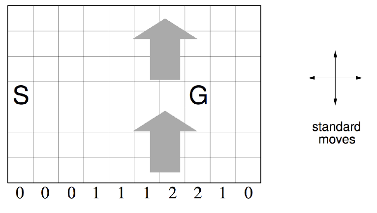

Windy gridworld example, image from D.Silver

## SARSA

SARSA is an on-policy control algorithm using temporal-difference learning. Given a state and action pair the next state $S'$ and Reward $R$ are sampled from the environment. Then following an $\epsilon$-greedy policy the next action $A'$ is sampled. The action value of $S$ and $A$ is then updated towards the observed reward plus a discounted (discount factor $\gamma$) of the subsequent state action pair $(S', A')$.

The update equation is:

$Q(S, A) \leftarrow Q(S, A) + \alpha[R + \gamma Q(S', A') - Q(S, A)]$

In the following we will solve the windy gridworld problem, i.e. find the shortest path from the start state to the goal state. First we load the `reinforcelearn` package and create the environment.

```r
library(reinforcelearn)
grid = WindyGridworld$new()
WindyGridworld1 = makeEnvironment(transition.array = grid$transition.array,
  reward.matrix = grid$reward.matrix,
  initial.state = 30L)
```

Then we can apply SARSA to find the optimal action value function $Q$. Here we will use SARSA(0), which only updates the current state action pair. Try different $\lambda$ values for a trade-off between temporal-difference and monte carlo learning.

```r
res = sarsa(WindyGridworld1, n.episodes = 1000, seed = 123)
```

Then we can find the optimal action value function $Q$ by taking the max over the $Q$ matrix and the optimal policy by taking the argmax with respect to $Q$.

```r
# Optimal action value function
optimal.Q = apply(res$Q, 1, max)
print(matrix(optimal.Q, ncol = 10, byrow = TRUE))
```

```
##           [,1]      [,2]      [,3]      [,4]       [,5]       [,6]
## [1,]   0.00000 -12.93338 -12.65839 -12.01088 -11.009644 -10.008070
## [2,] -13.93020 -13.38866 -12.77848 -11.98550 -11.007813 -10.000000
## [3,] -14.35863 -13.67718 -12.89128 -11.99216 -11.000000  -9.996444
## [4,] -15.00000 -14.00000 -13.00000 -12.00000 -10.954272  -9.779247
## [5,] -14.16764 -13.41819 -12.61263 -11.83074 -10.555916  -9.203334
## [6,] -13.41088 -12.81400 -12.06975 -11.31435  -9.945708   0.000000
## [7,] -12.88513 -12.26481 -11.52962 -10.70154   0.000000   0.000000
##           [,7]       [,8]      [,9]     [,10]
## [1,] -9.000000 -8.0000000 -7.000000 -6.000000
## [2,] -9.007241 -7.7713628 -5.581376 -5.000000
## [3,] -8.955000 -3.0789460 -4.192069 -4.000000
## [4,] -8.467603  0.0000000 -2.910956 -3.000000
## [5,]  0.000000 -0.5695328 -1.000000 -2.000000
## [6,]  0.000000  0.0000000 -1.032166 -1.474198
## [7,]  0.000000  0.0000000 -0.353800 -0.937372
```

```r
# Optimal policy
optimal.policy = max.col(res$Q)
print(matrix(optimal.policy, ncol = 10, byrow = TRUE))
```

```
##      [,1] [,2] [,3] [,4] [,5] [,6] [,7] [,8] [,9] [,10]
## [1,]    4    3    1    2    2    2    2    2    2     4
## [2,]    2    2    4    2    2    2    2    1    2     4
## [3,]    2    2    2    2    2    2    2    3    4     4
## [4,]    2    2    2    2    2    4    2    4    1     4
## [5,]    4    2    2    2    2    2    1    4    1     1
## [6,]    4    4    2    2    2    4    2    2    3     4
## [7,]    2    4    2    4    2    3    1    1    1     1
```

We can plot the number of time steps per episode. As expected the first episode takes quite a large number of time steps as we start wandering around randomly. With time the action value function $Q$ improves and therefore the policy gets better and need less time steps to finish an episode. The optimal policy takes 15 steps from the start state to the goal state.

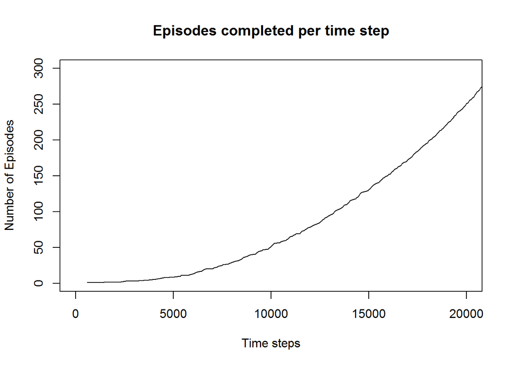

```r
plot(x = cumsum(res$steps.per.episode)[1:300], y = 1:300,
 type = "l", xlim = c(0, 20000), ylab = "Number of Episodes", xlab = "Time steps",
 main = "Episodes completed per time step")
```

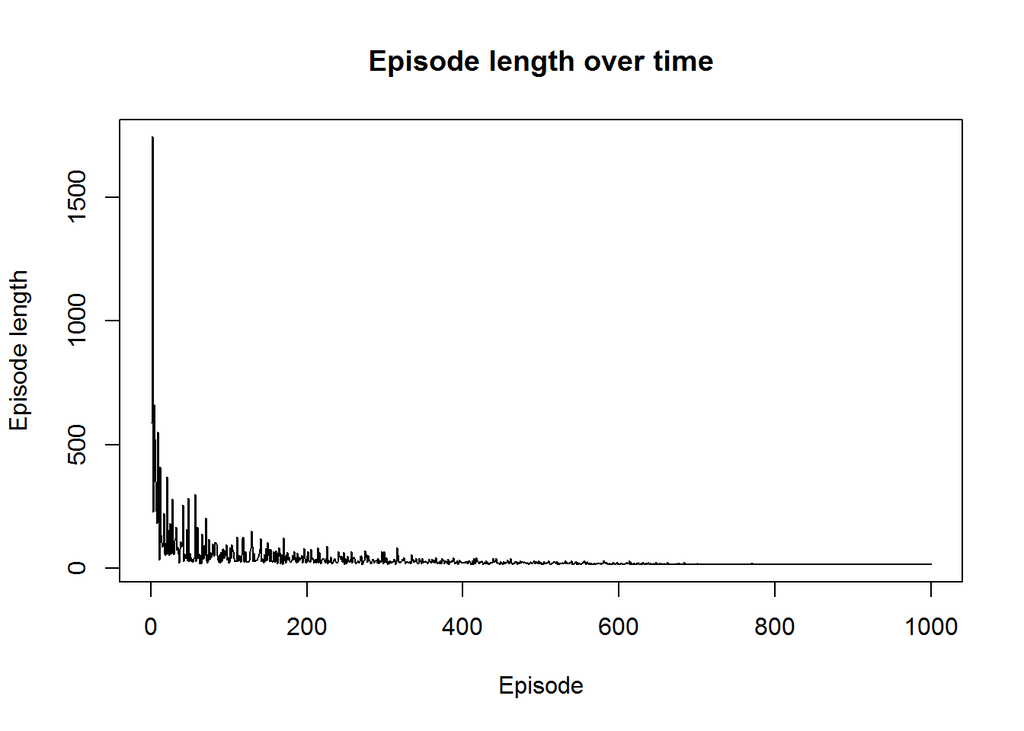

```r
plot(x = seq_along(res$steps.per.episode), y = res$steps.per.episode,
 type = "l", xlim = c(0, 1000), ylab = "Episode length", xlab = "Episode", main = "Episode length over time")
```

Graphically the optimal policy looks like:

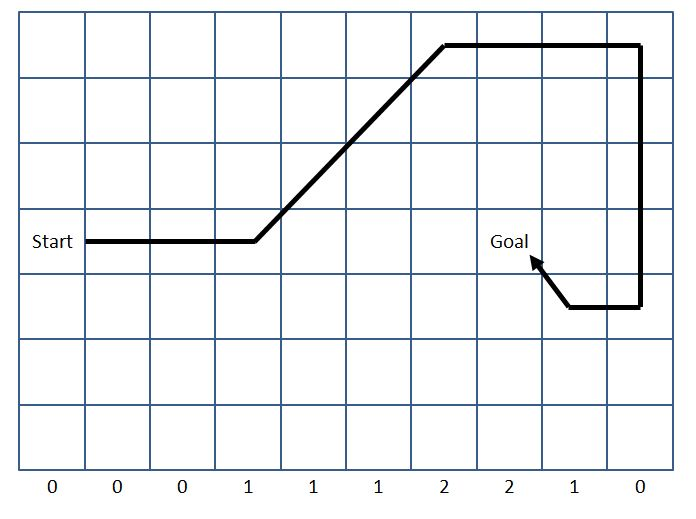

Optimal policy

## More Reinforcement Learning in R:

Learn more about reinforcement learning in R: reinforcelearn

## Bibliography

Sutton and Barto (Book draft 2016): Reinforcement Learning: An Introduction